# Adjustment and Confounding Variables: Air Pollution

Cartier Zhi

21/09/2021

## Introduction

This article hopes to address the issue of confounding variables in the context of air pollution investigation. We will investigate the distorting effect of traffic volume in the relationship between air pollutants and population of an area.

## Datasets: Traffic Volume, AQI and Population

Traffic Volume was obtained from the NSW government with information about traffic across the state of NSW. The variable count traffic_test describes the number of vehicles recorded by each traffic station. AQI was from the NSW government, describing specific air quality related variables in NSW. The population dataset was obtained from the ABS with populations (population_test) of each local government area in NSW. These datasets were combined to form a larger dataset which will enable us to analyse the relationship between air pollution, population and traffic.

## Scatter Plot

Let’s do an initial overview of the numeric variables. Below, we can see that traffic vs population, traffic vs NO, and NO vs population could potentially modelled via a linear regression.

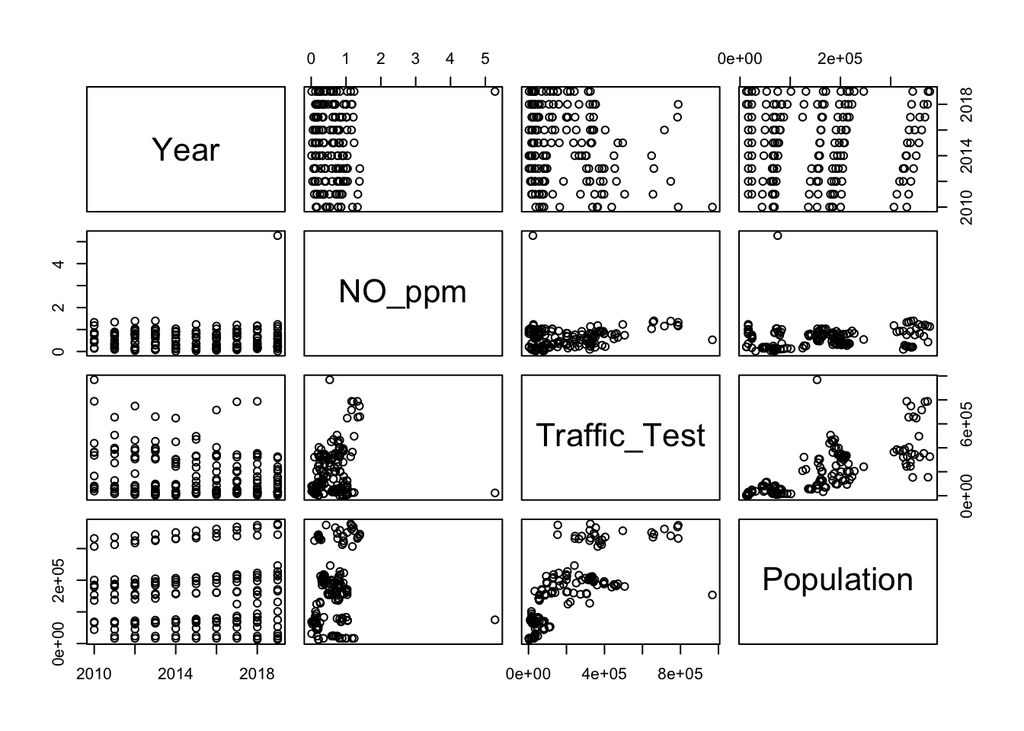

```r
pairs(NO_pop_traffic[2:5])
```

## Correlations

Using the base function, `cor()`, we can make a matrix of correlations between all the numeric variables. We can see that traffic_test has a positive relationship with population_test and NO value (population and value of nitric oxide parts per million increases when traffic increases). We can also see NO values are positive correlated with population. These findings confirmed the relationships seen in the scatter plots.

```r
cor_matrix <- cor(NO_pop_traffic[2:5])
cor_matrix
```

```
##                     Year     NO_ppm Traffic_Test Population
## Year          1.00000000 0.01847823   -0.1930029  0.0233862
## NO_ppm        0.01847823 1.00000000    0.2384179  0.1906320
## Traffic_Test -0.19300291 0.23841790    1.0000000  0.7464077
## Population    0.02338620 0.19063201    0.7464077  1.0000000
```

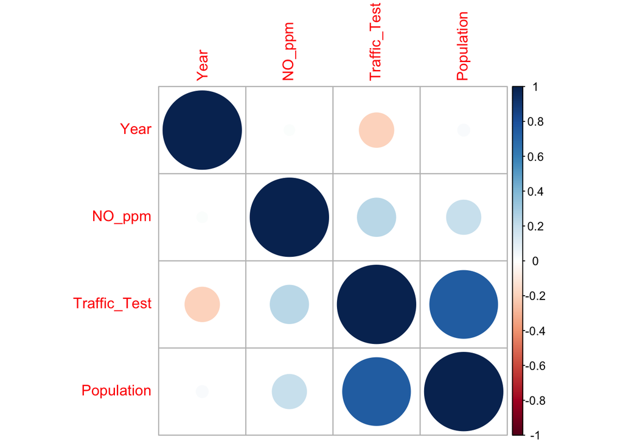

```r
corrplot::corrplot(cor_matrix)
```

## What does this mean?

Earlier, we saw that the variables, Nitric Oxide (ppm) and population have a positive relationship. This was also true of traffic with NO and population. This was seen in scatter plots and correlation plot. One could infer that there is a cause and effect relation between these variables with the evidence put forth from analysis. While this is a correct assumption for the relationships of traffic with NO and population, we can not say the same for NO vs populations. One can only judge this from context: we know that vehicles release NO and higher traffic levels is closely linked to denser populations, however, large populations in of itself do not cause high levels of NO. This is seen in the weaker correlation between NO and population compared to the other examined relationships. From this, we saw the confounding impact of traffic on NO vs population, causing a spurious correlation to be found in analysis. Recommendations for data practitioners to limit this issue occurring requires a high level of understanding of the data and the research problem. This can be aided by having higher levels of domain knowledge as well as guidance from domain experts.